# A mixture of a Poisson-lognormal distribution

Masatoshi Katabuchi

September 2018

[Twittter](https://twitter.com/mattocci) [Github](https://github.com/mattocci27/) Email

Here is a little example of fitting mixture model with R and Stan.

# 1 Mixture model

Given a set of likelihood functions $\pi_1(\boldsymbol y \mid \alpha_1), \ldots, \pi_k(\boldsymbol y \mid \alpha_K)$ for variables $\boldsymbol y = (y_1, \ldots, y_N)$, parameterized by $\boldsymbol \alpha = (\alpha_1, \ldots, \alpha_K)$ and mixture weights $\boldsymbol \theta = (\theta_1, \ldots, \theta_K)$ such that $0 \le \theta_{k} \le 1$ and $\sum\theta_{k} = 1$, the mixture likelihood is

$$\pi(\boldsymbol y \mid{\boldsymbol \alpha}, {\boldsymbol \theta}) = \sum_{k=1}^{K}\sum_{n=1}^{N}\theta_k \pi_k(y_n \mid \alpha_k).$$

# 2 Poisson-lognormal mixture model

Let’s consider a simple example where the likelihood is given by a mixture of two Poisson-lognormal [(PoiLog)](https://mattocci27.github.io/assets/poilog.html),

$$\pi(y_1, ..., y_N \mid \mu_1, \mu_2, \sigma_1,\sigma_2, \theta) = \sum_{n=1}^{N}\theta PoiLog(y_n \mid \mu_1, \sigma_1) + \sum_{n=1}^{N}(1-\theta) PoiLog(y_n \mid \mu_2, \sigma_2).$$

We define two different components of Poisson-lognormal distributions, $PoiLog(\mu_1 = log(50) \simeq 3.91, \sigma_1 = 0.8)$ and $PoiLog(\mu_2 = log(400) \simeq 5.99, \sigma_2 = 0.2)$ with the mixture weight $\theta = 0.8$

```r
mu <- c(log(50), log(400))
sigma <- c(0.8, 0.2)
theta <- 0.8
```

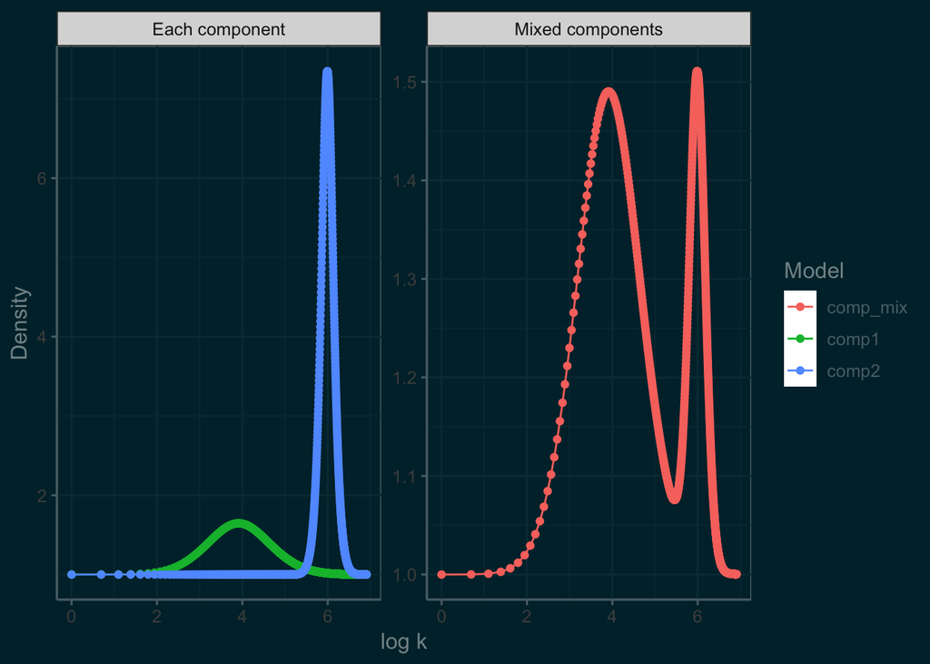

```r
library(cowplot)
library(ggthemes)
theme_set(theme_solarized(light=FALSE))

xx <- seq(1, 1000, by = 1)
y1 <- dnorm(log(xx), mu[1], sigma[1])
y2 <- dnorm(log(xx), mu[2], sigma[2])
y_mix <- theta * y1 + (1 - theta) * y2

line_dat <- data_frame(xx,
  comp1 = y1,
  comp2 = y2,
  comp_mix = y_mix) %>%
  gather(Model, val, 2:4) %>%
  mutate(model2 = ifelse(Model == "comp_mix",
                         "Mixed components",
                         "Each component"))

ggplot(line_dat, aes(x = xx %>% log, y = val %>% exp, col = Model)) +
  geom_line() +
  geom_point() +
  facet_wrap(~model2, scale = "free") +
  xlab("log k") +
  ylab("Density")
```

then we simulate data based on the above probability density.

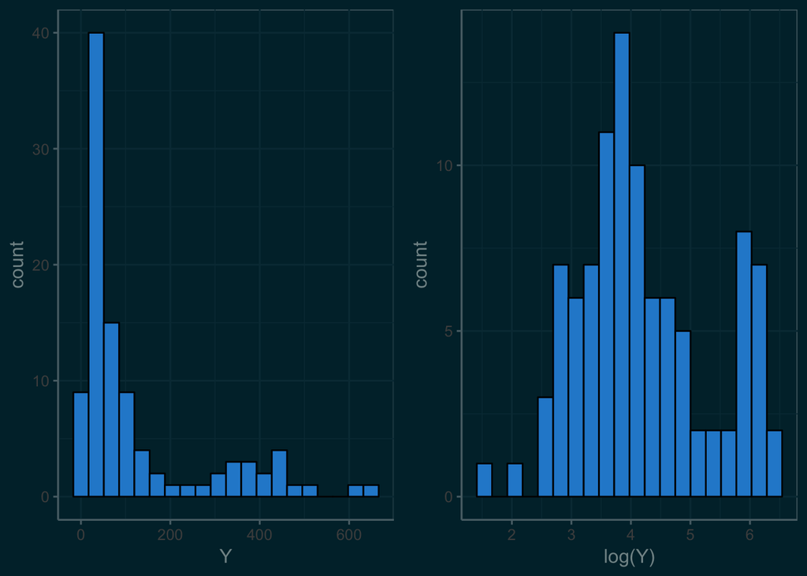

```r
set.seed(123)

N <- 100
z <- rbinom(N, 1, 1 - theta) + 1
log_lambda <- rnorm(N, mu[z], sigma[z])
Y <- rpois(N, exp(log_lambda))
#lambda <- rlnorm(N, mu[z] - 0.5 * sigma[z]^2, sigma[z])
#Y <- rpois(N, lambda)

hist_dat <- data_frame(Y)

p1 <- ggplot(hist_dat, aes(Y)) +
  geom_histogram(bins = 20, fill = "#268bd2", col = "black")

p2 <- ggplot(hist_dat, aes(log(Y))) +
  geom_histogram(bins = 20, fill = "#268bd2", col = "black")

plot_grid(p1, p2)
```

# 3 Testing

## 3.1 Centered parameterization

First, we fit the direct centered parameterization.

$$\mu_1,\mu_2 \sim \mathcal{N}(0, 10)$$

$$log\lambda_{1n} \sim \mathcal{N}(\mu_1, \sigma_1)$$

$$log\lambda_{2n} \sim \mathcal{N}(\mu_2, \sigma_2)$$

$$\theta \sim Beta(2, 2)$$

```r
writeLines(readLines("poilog_mix_cp.stan"))
```

```
## data{
##  int<lower=0> N;
##  int y[N];
## }
##
## parameters {
##   ordered[2] mu;
##   real<lower=0> sigma[2];
##   real<lower=0, upper=1> theta;
##   vector[N] log_lambda[2];
## }
## model {
##  sigma ~ cauchy(0, 2.5);
##  mu ~ normal(0, 10);
##  theta ~ beta(2, 2);
##  for (i in 1:2)
##   log_lambda[i,] ~ normal(mu[i], sigma[i]);
##  for (n in 1:N)
##   target += log_mix(theta,
##                     poisson_log_lpmf(y[n] | log_lambda[1, n]),
##                     poisson_log_lpmf(y[n] | log_lambda[2, n]));
## }
```

```r
library(rstan)
rstan_options(auto_write = TRUE)
options(mc.cores = parallel::detectCores())

list_dat <- list(N = N, y = Y)

fit_cp <- stan(file = "poilog_mix_cp.stan",
            data = list_dat,
            iter = 2000,
            warmup = 1000,
            thin = 1,
            chains =  4,
            refresh = 500,
            control = list(adapt_delta = 0.9, max_treedepth = 20))
```

The model did not converge well. Additionally, there were divergent transitions, which indicates that the simulated Hamiltonian diverges from the true Hamiltonian. **Even a few numbers of divergent transitions indicate serious bias on the estimates.**

```r
print(fit_cp,
      pars = c("mu", "sigma", "theta",
               "log_lambda[1,1]",
               "log_lambda[1,2]",
               "log_lambda[1,100]",
               "log_lambda[2,1]",
               "log_lambda[2,2]",
               "log_lambda[2,100]",
               "lp__"))
```

```
## Inference for Stan model: poilog_mix_cp.
## 4 chains, each with iter=2000; warmup=1000; thin=1;
## post-warmup draws per chain=1000, total post-warmup draws=4000.
##
##                      mean se_mean     sd    2.5%     25%     50%     75%
## mu[1]                3.92    0.12   0.20    3.66    3.78    3.86    4.04
## mu[2]                6.73    0.68   2.81    4.39    5.94    5.99    6.06
## sigma[1]             0.86    0.11   0.17    0.64    0.73    0.80    0.98
## sigma[2]             1.28    1.08   3.02    0.17    0.22    0.26    0.37
## theta                0.85    0.05   0.08    0.72    0.79    0.83    0.91
## log_lambda[1,1]      4.19    0.00   0.13    3.94    4.11    4.19    4.27
## log_lambda[1,2]      3.98    0.00   0.13    3.71    3.89    3.98    4.07
## log_lambda[1,100]    3.08    0.00   0.21    2.67    2.94    3.09    3.22
## log_lambda[2,1]      6.75    0.71   4.60    2.63    5.77    6.00    6.24
## log_lambda[2,2]      6.72    0.68   4.21    2.67    5.77    6.00    6.24
## log_lambda[2,100]    6.75    0.71   4.23    2.81    5.78    6.00    6.24
## lp__              -391.00   63.61 113.81 -715.46 -380.54 -345.35 -327.57
##                     97.5% n_eff Rhat
## mu[1]                4.36     2 2.13
## mu[2]               17.09    17 1.22
## sigma[1]             1.22     2 2.23
## sigma[2]            11.05     8 1.96
## theta                0.99     2 2.28
## log_lambda[1,1]      4.41  2297 1.00
## log_lambda[1,2]      4.24  4000 1.00
## log_lambda[1,100]    3.46  4000 1.00
## log_lambda[2,1]     19.39    42 1.08
## log_lambda[2,2]     18.64    38 1.08
## log_lambda[2,100]   19.79    35 1.09
## lp__              -300.65     3 3.63
##
## Samples were drawn using NUTS(diag_e) at Thu Sep 27 11:22:27 2018.
## For each parameter, n_eff is a crude measure of effective sample size,
## and Rhat is the potential scale reduction factor on split chains (at
## convergence, Rhat=1).
```

## 3.2 Non-Centered parameterization

Instead of sampling $log\lambda_{1n}$ and $log\lambda_{2n}$ directly, the model can be converted to the following more efficient form,

$$\mu_1,\mu_2 \sim \mathcal{N}(0, 10)$$

$$log\tilde\lambda_{1n},log\tilde\lambda_{2n} \sim \mathcal{N}(0,1)$$

$$log\lambda_{1n} = \mu_1 + log\tilde\lambda_{1n} \times \sigma_1$$

$$log\lambda_{2n} = \mu_2 + log\tilde\lambda_{2n} \times \sigma_2$$

$$\theta \sim Beta(2, 2)$$

```r
writeLines(readLines("poilog_mix_ncp.stan"))
```

```
## data{
##  int<lower=0> N;
##  int y[N];
## }
##
## parameters {
##   ordered[2] mu;
##   real<lower=0> sigma[2];
##   real<lower=0, upper=1> theta;
##   vector[N] log_lambda_tilde[2];
## }
## transformed parameters {
##   vector[N] log_lambda[2];
##   for (i in 1:2)
##     log_lambda[i,] = mu[i] + log_lambda_tilde[i,] * sigma[i];
## }
##
## model {
##  sigma ~ cauchy(0, 2.5);
##  mu ~ normal(0, 10);
##  theta ~ beta(2, 2);
##  for (i in 1:2)
##    log_lambda_tilde[i, ] ~ normal(0, 1);
##
##  for (n in 1:N)
##   target += log_mix(theta,
##                     poisson_log_lpmf(y[n] | log_lambda[1, n]),
##                     poisson_log_lpmf(y[n] | log_lambda[2, n]));
## }
```

This non-centered parameterization exchanges a direct dependence between ($\mu$, $\sigma$) and $log\lambda$ for a dependence between ($\mu$, $\sigma$) and $y_i$, which would reduce the dependence between $\lambda$, $\mu$, and $\sigma$.

```r
fit_ncp <- stan(file = "poilog_mix_ncp.stan",
            data = list_dat,
            iter = 2000,
            warmup = 1000,
            thin = 1,
            chains =  4,
            refresh = 500,
            control = list(adapt_delta = 0.9, max_treedepth = 20))
```

Now we don’t have divergent transitions. The resulting estimates well recovered the original values ($\boldsymbol \mu$, $\boldsymbol \sigma$ and $\theta$) 🍺. Note that the above model will not work very well when the two components are relatively close ([see detailed explanation](https://betanalpha.github.io/assets/case_studies/identifying_mixture_models.html)).

```r
print(fit_ncp,
      pars = c("mu", "sigma", "theta",
               "log_lambda[1,1]",
               "log_lambda[1,2]",
               "log_lambda[1,100]",
               "log_lambda[2,1]",
               "log_lambda[2,2]",
               "log_lambda[2,100]",
               "lp__"))
```

```
## Inference for Stan model: poilog_mix_ncp.
## 4 chains, each with iter=2000; warmup=1000; thin=1;
## post-warmup draws per chain=1000, total post-warmup draws=4000.
##
##                      mean se_mean    sd    2.5%     25%     50%     75%
## mu[1]                3.79    0.01  0.09    3.62    3.73    3.79    3.85
## mu[2]                5.97    0.01  0.07    5.83    5.93    5.97    6.02
## sigma[1]             0.75    0.01  0.09    0.61    0.69    0.74    0.80
## sigma[2]             0.26    0.01  0.07    0.16    0.21    0.25    0.30
## theta                0.80    0.00  0.04    0.71    0.77    0.80    0.83
## log_lambda[1,1]      4.18    0.00  0.12    3.94    4.10    4.19    4.27
## log_lambda[1,2]      3.97    0.00  0.14    3.70    3.88    3.98    4.07
## log_lambda[1,100]    3.08    0.00  0.20    2.67    2.95    3.09    3.23
## log_lambda[2,1]      5.97    0.00  0.29    5.37    5.80    5.97    6.15
## log_lambda[2,2]      5.97    0.00  0.29    5.40    5.79    5.98    6.16
## log_lambda[2,100]    5.98    0.00  0.28    5.41    5.81    5.98    6.15
## lp__              -505.78    0.65 13.07 -532.06 -514.33 -505.31 -496.95
##                     97.5% n_eff Rhat
## mu[1]                3.96   112 1.02
## mu[2]                6.11   135 1.05
## sigma[1]             0.96    86 1.04
## sigma[2]             0.43    83 1.02
## theta                0.88  4000 1.01
## log_lambda[1,1]      4.42  4000 1.00
## log_lambda[1,2]      4.23  4000 1.00
## log_lambda[1,100]    3.47  4000 1.00
## log_lambda[2,1]      6.54  4000 1.00
## log_lambda[2,2]      6.53  4000 1.00
## log_lambda[2,100]    6.53  4000 1.00
## lp__              -481.13   403 1.01
##
## Samples were drawn using NUTS(diag_e) at Thu Sep 27 11:23:14 2018.
## For each parameter, n_eff is a crude measure of effective sample size,
## and Rhat is the potential scale reduction factor on split chains (at
## convergence, Rhat=1).
```

# 4 Computing Environment

```r
writeLines(readLines(file.path(Sys.getenv("HOME"), ".R/Makevars")))
```

```
## CXXFLAGS=-O3 -mtune=native -march=native -Wno-unused-variable -Wno-unused-function
## CC=clang
## CXX=clang++ -arch x86_64 -ftemplate-depth-256
```

```
##  setting  value
##  version  R version 3.5.1 (2018-07-02)
##  system   x86_64, darwin17.7.0
##  ui       unknown
##  language (EN)
##  collate  en_US.UTF-8
##  tz       America/Detroit
##  date     2018-09-27
```

```
## Packages -----------------------------------------------------------------
```

```
##  package      * version   date       source
##  assertthat     0.2.0     2017-04-11 CRAN (R 3.5.0)
##  BH             1.66.0-1  2018-02-13 CRAN (R 3.5.0)
##  cli            1.0.0     2017-11-05 CRAN (R 3.5.0)
##  colorspace     1.3-2     2016-12-14 CRAN (R 3.5.0)
##  crayon         1.3.4     2017-09-16 CRAN (R 3.5.0)
##  digest         0.6.15    2018-01-28 CRAN (R 3.5.0)
##  ggplot2      * 3.0.0     2018-07-03 cran (@3.0.0)
##  glue           1.3.0     2018-09-21 Github (tidyverse/glue@4e74901)
##  graphics     * 3.5.1     2018-07-26 local
##  grDevices    * 3.5.1     2018-07-26 local
##  grid           3.5.1     2018-07-26 local
##  gridExtra      2.3       2017-09-09 CRAN (R 3.5.0)
##  gtable         0.2.0     2016-02-26 CRAN (R 3.5.0)
##  inline         0.3.15    2018-05-18 CRAN (R 3.5.0)
##  labeling       0.3       2014-08-23 CRAN (R 3.5.0)
##  lattice        0.20-35   2017-03-25 CRAN (R 3.5.1)
##  lazyeval       0.2.1     2017-10-29 CRAN (R 3.5.0)
##  magrittr       1.5       2014-11-22 CRAN (R 3.5.0)
##  MASS           7.3-50    2018-04-30 CRAN (R 3.5.1)
##  Matrix         1.2-14    2018-04-13 CRAN (R 3.5.1)
##  methods      * 3.5.1     2018-07-26 local
##  mgcv           1.8-24    2018-06-23 CRAN (R 3.5.1)
##  munsell        0.5.0     2018-06-12 CRAN (R 3.5.0)
##  nlme           3.1-137   2018-04-07 CRAN (R 3.5.1)
##  pillar         1.2.3     2018-05-25 CRAN (R 3.5.0)
##  plyr           1.8.4     2016-06-08 CRAN (R 3.5.0)
##  R6             2.2.2     2017-06-17 CRAN (R 3.5.0)
##  RColorBrewer   1.1-2     2014-12-07 CRAN (R 3.5.1)
##  Rcpp           0.12.18   2018-07-23 cran (@0.12.18)
##  RcppEigen      0.3.3.4.0 2018-02-07 CRAN (R 3.5.0)
##  reshape2       1.4.3     2017-12-11 CRAN (R 3.5.0)
##  rlang          0.2.2     2018-08-16 cran (@0.2.2)
##  rstan        * 2.17.3    2018-01-20 CRAN (R 3.5.0)
##  scales         1.0.0     2018-08-09 cran (@1.0.0)
##  StanHeaders  * 2.17.2    2018-01-20 CRAN (R 3.5.0)
##  stats        * 3.5.1     2018-07-26 local
##  stats4         3.5.1     2018-07-26 local
##  stringi        1.2.3     2018-06-12 CRAN (R 3.5.0)
##  stringr      * 1.3.1     2018-05-10 CRAN (R 3.5.0)
##  tibble       * 1.4.2     2018-01-22 CRAN (R 3.5.0)
##  tools          3.5.1     2018-07-26 local
##  utf8           1.1.4     2018-05-24 CRAN (R 3.5.0)
##  utils        * 3.5.1     2018-07-26 local
##  viridisLite    0.3.0     2018-02-01 CRAN (R 3.5.0)
##  withr          2.1.2     2018-03-15 CRAN (R 3.5.0)
```

# 5 Related

- [Mixture model (wiki)](https://en.wikipedia.org/wiki/Mixture_model)
- [Fitting a Poisson-lognormal distribution in Stan (rstan)](https://mattocci27.github.io/assets/poilog.html)
- [Diagnosing Biased Inference with Divergences](https://betanalpha.github.io/assets/case_studies/divergences_and_bias.html#3_a_non-centered_eight_schools_implementation)
- [Identifying Bayesian Mixture Models](https://betanalpha.github.io/assets/case_studies/identifying_mixture_models.html)
- [Poisson-LogSkewNormal mixture + partial pooling](https://discourse.mc-stan.org/t/poisson-logskewnormal-mixture-partial-pooling/2189)

# References

Betancourt, M. J., and Mark Girolami. 2013. “Hamiltonian Monte Carlo for Hierarchical Models,” December. http://arxiv.org/abs/1312.0906.